# Optimal Treatment Analysis

## Outcome Variable

**Outcome Variable:** whz

## Predictor Variables

**Intervention Variable:** cleanck

**Adjustment Set:**

- arm
- sex
- W_mage
- meducyrs
- feducyrs
- hhwealth_quart
- W_nrooms
- W_nhh
- W_nchldlt5
- trth2o
- impfloor
- delta_meducyrs
- delta_feducyrs
- delta_hhwealth_quart
- delta_W_nrooms
- delta_W_nhh
- delta_W_nchldlt5
- delta_trth2o
- delta_impfloor

## Stratifying Variables

The analysis was stratified on these variable(s):

- agecat
- studyid
- country

## Data Summary

| agecat | studyid | country | cleanck | n_cell | n |
| --- | --- | --- | --- | --- | --- |
| Birth | ki0047075b-MAL-ED | PERU | 1 | 1 | 2 |
| Birth | ki0047075b-MAL-ED | PERU | 0 | 1 | 2 |
| Birth | ki1000108-CMC-V-BCS-2002 | INDIA | 1 | 37 | 86 |
| Birth | ki1000108-CMC-V-BCS-2002 | INDIA | 0 | 49 | 86 |
| Birth | ki1000108-IRC | INDIA | 1 | 198 | 337 |
| Birth | ki1000108-IRC | INDIA | 0 | 139 | 337 |
| Birth | ki1017093b-PROVIDE | BANGLADESH | 1 | 433 | 532 |
| Birth | ki1017093b-PROVIDE | BANGLADESH | 0 | 99 | 532 |
| Birth | ki1017093c-NIH-Crypto | BANGLADESH | 1 | 336 | 543 |
| Birth | ki1017093c-NIH-Crypto | BANGLADESH | 0 | 207 | 543 |
| Birth | ki1113344-GMS-Nepal | NEPAL | 1 | 9 | 570 |
| Birth | ki1113344-GMS-Nepal | NEPAL | 0 | 561 | 570 |
| 6 months | ki0047075b-MAL-ED | SOUTH AFRICA | 1 | 1 | 1 |
| 6 months | ki0047075b-MAL-ED | SOUTH AFRICA | 0 | 0 | 1 |
| 6 months | ki1000108-CMC-V-BCS-2002 | INDIA | 1 | 162 | 368 |
| 6 months | ki1000108-CMC-V-BCS-2002 | INDIA | 0 | 206 | 368 |
| 6 months | ki1000108-IRC | INDIA | 1 | 229 | 398 |
| 6 months | ki1000108-IRC | INDIA | 0 | 169 | 398 |
| 6 months | ki1017093b-PROVIDE | BANGLADESH | 1 | 497 | 603 |
| 6 months | ki1017093b-PROVIDE | BANGLADESH | 0 | 106 | 603 |
| 6 months | ki1017093c-NIH-Crypto | BANGLADESH | 1 | 329 | 545 |
| 6 months | ki1017093c-NIH-Crypto | BANGLADESH | 0 | 216 | 545 |
| 6 months | ki1113344-GMS-Nepal | NEPAL | 1 | 8 | 505 |
| 6 months | ki1113344-GMS-Nepal | NEPAL | 0 | 497 | 505 |
| 24 months | ki0047075b-MAL-ED | SOUTH AFRICA | 1 | 1 | 1 |
| 24 months | ki0047075b-MAL-ED | SOUTH AFRICA | 0 | 0 | 1 |
| 24 months | ki1000108-CMC-V-BCS-2002 | INDIA | 1 | 163 | 372 |
| 24 months | ki1000108-CMC-V-BCS-2002 | INDIA | 0 | 209 | 372 |
| 24 months | ki1000108-IRC | INDIA | 1 | 231 | 400 |
| 24 months | ki1000108-IRC | INDIA | 0 | 169 | 400 |
| 24 months | ki1017093b-PROVIDE | BANGLADESH | 1 | 480 | 579 |
| 24 months | ki1017093b-PROVIDE | BANGLADESH | 0 | 99 | 579 |
| 24 months | ki1017093c-NIH-Crypto | BANGLADESH | 1 | 199 | 410 |
| 24 months | ki1017093c-NIH-Crypto | BANGLADESH | 0 | 211 | 410 |
| 24 months | ki1113344-GMS-Nepal | NEPAL | 1 | 5 | 434 |
| 24 months | ki1113344-GMS-Nepal | NEPAL | 0 | 429 | 434 |

The following strata were considered:

- agecat: 24 months, studyid: ki0047075b-MAL-ED, country: SOUTH AFRICA
- agecat: 24 months, studyid: ki1000108-CMC-V-BCS-2002, country: INDIA
- agecat: 24 months, studyid: ki1000108-IRC, country: INDIA
- agecat: 24 months, studyid: ki1017093b-PROVIDE, country: BANGLADESH
- agecat: 24 months, studyid: ki1017093c-NIH-Crypto, country: BANGLADESH
- agecat: 24 months, studyid: ki1113344-GMS-Nepal, country: NEPAL
- agecat: 6 months, studyid: ki0047075b-MAL-ED, country: SOUTH AFRICA
- agecat: 6 months, studyid: ki1000108-CMC-V-BCS-2002, country: INDIA
- agecat: 6 months, studyid: ki1000108-IRC, country: INDIA
- agecat: 6 months, studyid: ki1017093b-PROVIDE, country: BANGLADESH
- agecat: 6 months, studyid: ki1017093c-NIH-Crypto, country: BANGLADESH
- agecat: 6 months, studyid: ki1113344-GMS-Nepal, country: NEPAL
- agecat: Birth, studyid: ki0047075b-MAL-ED, country: PERU
- agecat: Birth, studyid: ki1000108-CMC-V-BCS-2002, country: INDIA
- agecat: Birth, studyid: ki1000108-IRC, country: INDIA
- agecat: Birth, studyid: ki1017093b-PROVIDE, country: BANGLADESH
- agecat: Birth, studyid: ki1017093c-NIH-Crypto, country: BANGLADESH
- agecat: Birth, studyid: ki1113344-GMS-Nepal, country: NEPAL

### Dropped Strata

Some strata were dropped due to rare outcomes:

- agecat: Birth, studyid: ki0047075b-MAL-ED, country: PERU
- agecat: 6 months, studyid: ki0047075b-MAL-ED, country: SOUTH AFRICA
- agecat: 24 months, studyid: ki0047075b-MAL-ED, country: SOUTH AFRICA

## Methods Detail

We’re interested in the causal parameters $E[Y_a]$ for all values of $a \in \mathcal{A}$. These parameters represent the mean outcome if, possibly contrary to fact, we intervened to set all units to have $A=a$. Under the randomization and positivity assumptions, these are identified by the statistical parameters $\psi_a=E_W[E_{Y|A,W}(Y|A=a,W)]$. In addition, we’re interested in the mean of $Y$, $E[Y]$ under no intervention (the observed mean). We will estimate these parameters by using SuperLearner to fit the relevant likelihood factors – $E_{Y|A,W}(Y|A=a,W)$ and $p(A=a|W)$, and then updating our likelihood fit using a joint TMLE.

For unadjusted analyses ($W=\{\}$), initial likelihoods were estimated using Lrnr_glm to estimate the simple $E(Y|A)$ and Lrnr_mean to estimate $p(A)$. For adjusted analyses, a small library containing Lrnr_glmnet, Lrnr_xgboost, and Lrnr_mean was used.

Having estimated these parameters, we will then use the delta method to estimate relative risks and attributable risks relative to a prespecified baseline level of $A$.

# Results Detail

## Results Plots

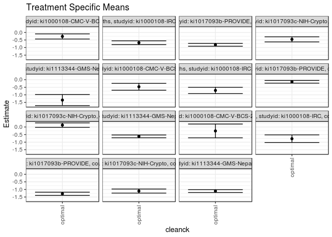

## Results Table

### Parameter: TSM

| agecat | studyid | country | intervention_level | baseline_level | estimate | ci_lower | ci_upper |
| --- | --- | --- | --- | --- | --- | --- | --- |
| Birth | ki1000108-CMC-V-BCS-2002 | INDIA | optimal | observed | -0.2609011 | -0.7155978 | 0.1937956 |
| Birth | ki1000108-IRC | INDIA | optimal | observed | -0.7733039 | -1.0250621 | -0.5215457 |
| Birth | ki1017093b-PROVIDE | BANGLADESH | optimal | observed | -1.2870910 | -1.3914404 | -1.1827415 |
| Birth | ki1017093c-NIH-Crypto | BANGLADESH | optimal | observed | -1.1068606 | -1.2422147 | -0.9715064 |
| Birth | ki1113344-GMS-Nepal | NEPAL | optimal | observed | -1.1081228 | -1.2024405 | -1.0138050 |
| 6 months | ki1000108-CMC-V-BCS-2002 | INDIA | optimal | observed | -0.4644514 | -0.6924225 | -0.2364804 |
| 6 months | ki1000108-IRC | INDIA | optimal | observed | -0.7082707 | -0.9160272 | -0.5005142 |
| 6 months | ki1017093b-PROVIDE | BANGLADESH | optimal | observed | -0.1389933 | -0.2286875 | -0.0492992 |
| 6 months | ki1017093c-NIH-Crypto | BANGLADESH | optimal | observed | 0.1243240 | -0.0220995 | 0.2707476 |
| 6 months | ki1113344-GMS-Nepal | NEPAL | optimal | observed | -0.6195238 | -0.7114355 | -0.5276121 |
| 24 months | ki1000108-CMC-V-BCS-2002 | INDIA | optimal | observed | -0.2662881 | -0.4361084 | -0.0964677 |
| 24 months | ki1000108-IRC | INDIA | optimal | observed | -0.6817357 | -0.8078072 | -0.5556641 |
| 24 months | ki1017093b-PROVIDE | BANGLADESH | optimal | observed | -0.8182236 | -0.9122198 | -0.7242275 |
| 24 months | ki1017093c-NIH-Crypto | BANGLADESH | optimal | observed | -0.4590115 | -0.6270262 | -0.2909967 |
| 24 months | ki1113344-GMS-Nepal | NEPAL | optimal | observed | -1.3447343 | -1.7096095 | -0.9798591 |

### Parameter: E(Y)

| agecat | studyid | country | intervention_level | baseline_level | estimate | ci_lower | ci_upper |
| --- | --- | --- | --- | --- | --- | --- | --- |
| Birth | ki1000108-CMC-V-BCS-2002 | INDIA | observed | observed | -0.4648256 | -0.7643210 | -0.1653302 |
| Birth | ki1000108-IRC | INDIA | observed | observed | -0.9860831 | -1.1746070 | -0.7975591 |
| Birth | ki1017093b-PROVIDE | BANGLADESH | observed | observed | -1.2984586 | -1.3752758 | -1.2216415 |
| Birth | ki1017093c-NIH-Crypto | BANGLADESH | observed | observed | -1.1841160 | -1.2799097 | -1.0883224 |
| Birth | ki1113344-GMS-Nepal | NEPAL | observed | observed | -1.1144386 | -1.2074618 | -1.0214154 |
| 6 months | ki1000108-CMC-V-BCS-2002 | INDIA | observed | observed | -0.5026766 | -0.6536848 | -0.3516685 |
| 6 months | ki1000108-IRC | INDIA | observed | observed | -0.6153685 | -0.7522411 | -0.4784959 |
| 6 months | ki1017093b-PROVIDE | BANGLADESH | observed | observed | -0.1990907 | -0.2817968 | -0.1163845 |
| 6 months | ki1017093c-NIH-Crypto | BANGLADESH | observed | observed | 0.0640826 | -0.0252594 | 0.1534245 |
| 6 months | ki1113344-GMS-Nepal | NEPAL | observed | observed | -0.6230627 | -0.7131245 | -0.5330009 |
| 24 months | ki1000108-CMC-V-BCS-2002 | INDIA | observed | observed | -0.5571505 | -0.6585247 | -0.4557763 |
| 24 months | ki1000108-IRC | INDIA | observed | observed | -0.7479083 | -0.8403586 | -0.6554581 |
| 24 months | ki1017093b-PROVIDE | BANGLADESH | observed | observed | -0.8928670 | -0.9755153 | -0.8102187 |
| 24 months | ki1017093c-NIH-Crypto | BANGLADESH | observed | observed | -0.5518293 | -0.6602513 | -0.4434072 |
| 24 months | ki1113344-GMS-Nepal | NEPAL | observed | observed | -1.1247312 | -1.2195989 | -1.0298635 |

### Parameter: PAR

| agecat | studyid | country | intervention_level | baseline_level | estimate | ci_lower | ci_upper |
| --- | --- | --- | --- | --- | --- | --- | --- |
| Birth | ki1000108-CMC-V-BCS-2002 | INDIA | optimal | observed | -0.2039245 | -0.5497230 | 0.1418740 |
| Birth | ki1000108-IRC | INDIA | optimal | observed | -0.2127792 | -0.3754001 | -0.0501583 |
| Birth | ki1017093b-PROVIDE | BANGLADESH | optimal | observed | -0.0113677 | -0.0896007 | 0.0668653 |
| Birth | ki1017093c-NIH-Crypto | BANGLADESH | optimal | observed | -0.0772555 | -0.1713371 | 0.0168262 |
| Birth | ki1113344-GMS-Nepal | NEPAL | optimal | observed | -0.0063158 | -0.0205230 | 0.0078913 |
| 6 months | ki1000108-CMC-V-BCS-2002 | INDIA | optimal | observed | -0.0382252 | -0.2162063 | 0.1397559 |
| 6 months | ki1000108-IRC | INDIA | optimal | observed | 0.0929022 | -0.0636099 | 0.2494143 |
| 6 months | ki1017093b-PROVIDE | BANGLADESH | optimal | observed | -0.0600973 | -0.1002306 | -0.0199640 |
| 6 months | ki1017093c-NIH-Crypto | BANGLADESH | optimal | observed | -0.0602415 | -0.1704412 | 0.0499583 |
| 6 months | ki1113344-GMS-Nepal | NEPAL | optimal | observed | -0.0035389 | -0.0128424 | 0.0057646 |
| 24 months | ki1000108-CMC-V-BCS-2002 | INDIA | optimal | observed | -0.2908625 | -0.4248863 | -0.1568387 |
| 24 months | ki1000108-IRC | INDIA | optimal | observed | -0.0661727 | -0.1484761 | 0.0161308 |
| 24 months | ki1017093b-PROVIDE | BANGLADESH | optimal | observed | -0.0746434 | -0.1253195 | -0.0239672 |
| 24 months | ki1017093c-NIH-Crypto | BANGLADESH | optimal | observed | -0.0928178 | -0.2085020 | 0.0228663 |
| 24 months | ki1113344-GMS-Nepal | NEPAL | optimal | observed | 0.2200031 | -0.1463496 | 0.5863559 |